# Aides Drug

Ariana Rodriguez

18 November 2019

# Introduction

# Methods

## Question 1: Is the vaccine effective for the total population?

$H_0$ The vaccine has no effect on whether one contracts aids or not.  
$H_1$ The vaccine affects whether one contracts aids or not.

# Results

## Descriptive Results

### Graphical Descriptive Results

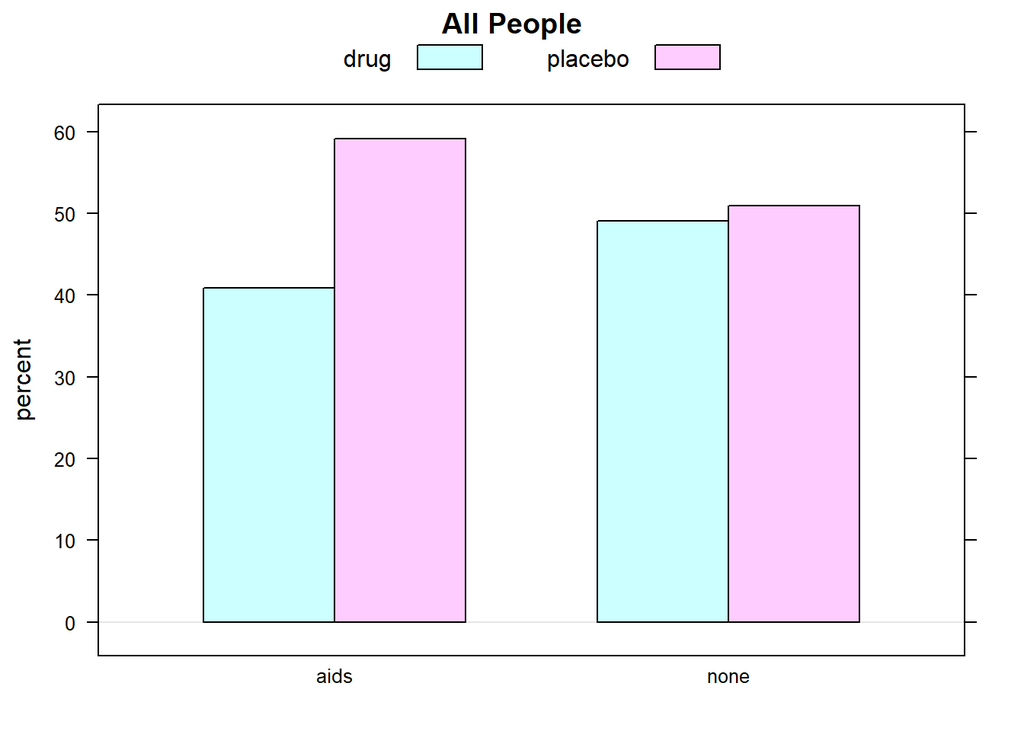

```r
barchartGC(~infected + treatment, data = avast, main = 'All People' , type = 'percent')
```

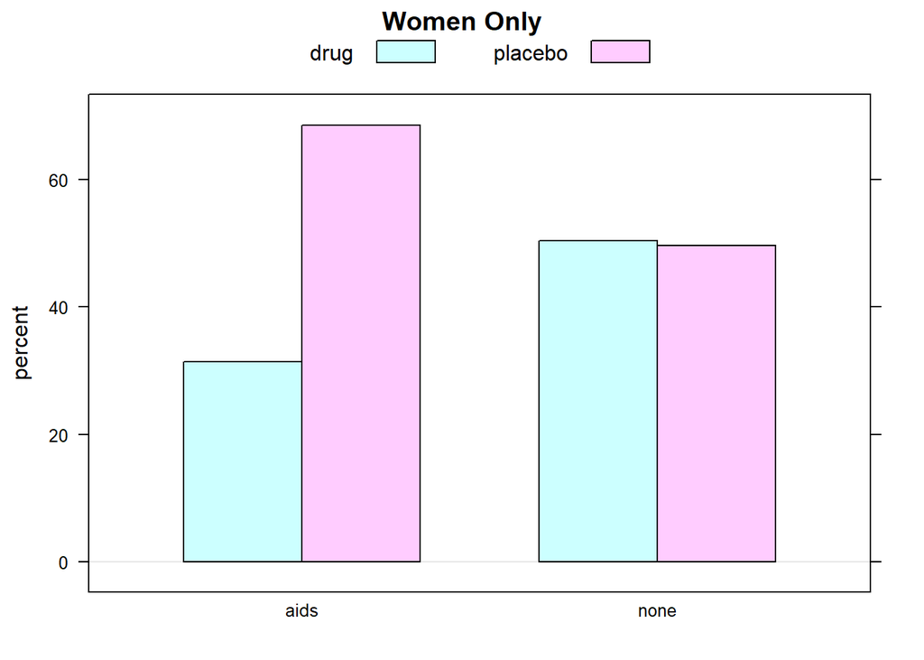

```r
barchartGC(~infected + treatment, data = filter(avast, sex == 'gal'), main = 'Women Only', type = 'percent')
```

This barchart shows that a little more than half of the women who took the placebo contracted aids compared to those that took the vaccine, and of those who did not contract aids, the effect of the vaccine and placebo was about the same.

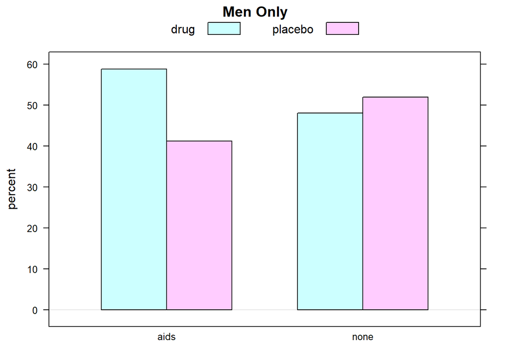

```r
barchartGC(~infected + treatment, data = filter(avast, sex == 'guy'), main = 'Men Only', type = 'percent')
```

This barchart shows that more men who took the vaccine contracted aids by about one-third compared to those who took the placebo and for the men who do not have aids, the effect of the placebo seemed to be slightly more effecient.

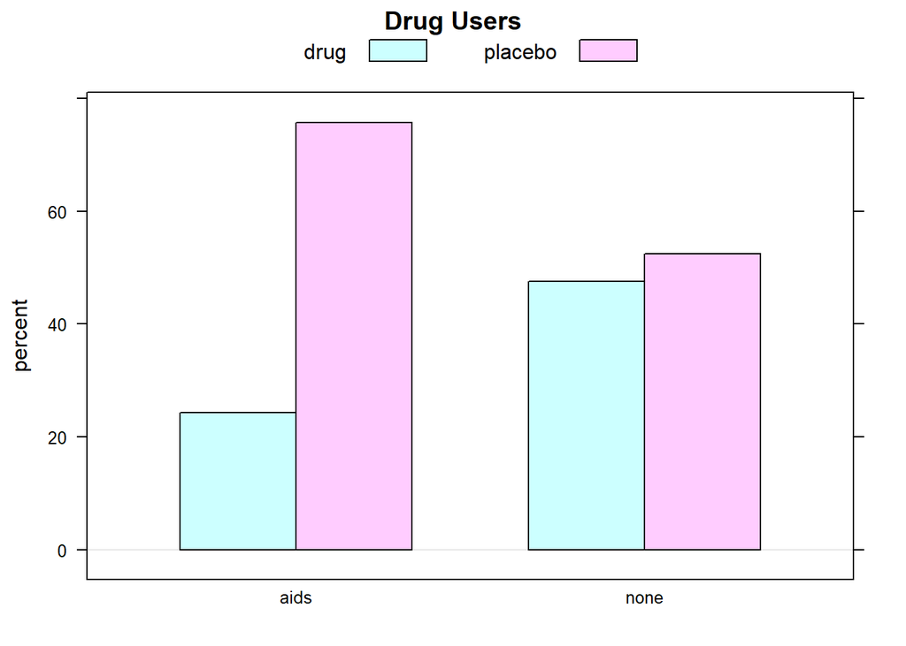

```r
barchartGC(~infected + treatment, data = filter(avast, DrugUser == 'yes'), main = 'Drug Users', type = 'percent')
```

This barchart shows that for drug users the effect of the vaccine proved to be more effective than the placebo because almost three times as many people who took the placebo contracted aids compared to those who took the vaccine. For the drug users that did not contract aids, the effect of the vaccine and the placebo was about the same with the placebo being slightly more effective.

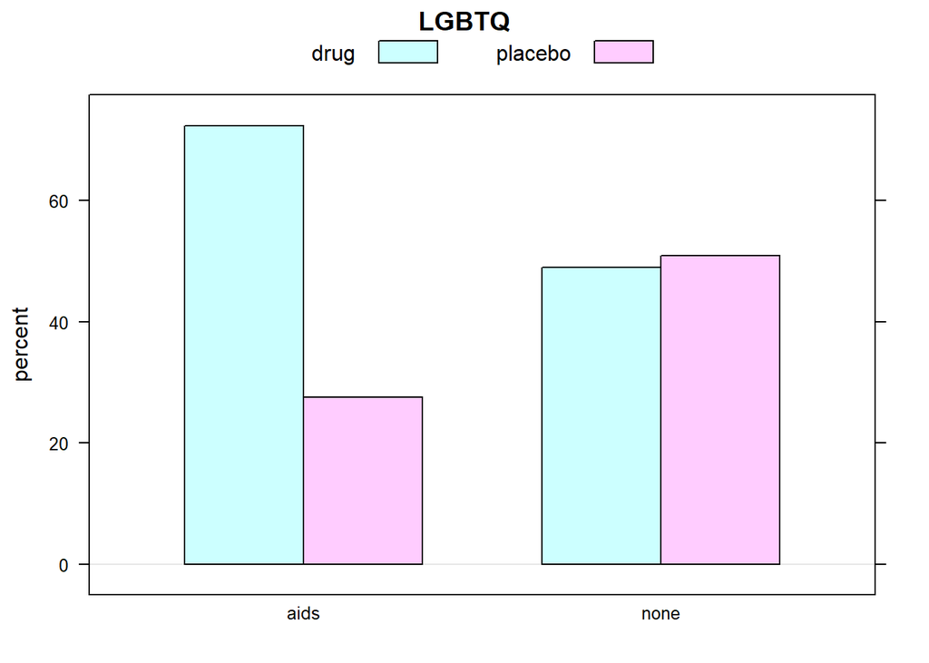

```r
barchartGC(~infected + treatment, data = filter(avast, LGBTQ == 'gay'), main = 'LGBTQ', type = 'percent')
```

This barchart shows that the number of LGBTQ people who have aids and were taking the vaccine was significantly higher by more than half the number of people who have aids and were taking the placebo. For the LGBTQ people who do not have aids, the effect of the placebo and the vaccine was about the same.

### Numerical Descriptive Results

```r
allPeople = xtabs(~infected + treatment, data = avast)
rowPerc(allPeople)
```

```
##         treatment
## infected   drug placebo  Total
##     aids  40.87   59.13 100.00
##     none  49.10   50.90 100.00
```

This table shows that about one and a half more of the people who took the placebo contracted aids compared to those that took the vaccine. Of the people who did not contract aids, the effect of the vaccine and the placebo was about the same.

```r
gal = xtabs(~infected + treatment, data = avast, sex == 'gal')
rowPerc(gal)
```

```
##         treatment
## infected   drug placebo  Total
##     aids  31.42   68.58 100.00
##     none  50.38   49.62 100.00
```

This table shows that more than half of the women who have aids did not take the vaccine and the effect of both the vaccine and the placebo was about the same for those who do not have aids.

```r
guy = xtabs(~infected + treatment, data = avast, sex == 'guy')
rowPerc(guy)
```

```
##         treatment
## infected   drug placebo  Total
##     aids  58.82   41.18 100.00
##     none  48.06   51.94 100.00
```

This table shows that almost 20% more men who were taking the vaccine contracted aids compared to those that were taking the placebo. The effect of both the vaccine and the placebo proved to be about the same with only about a 3% difference of the placebo being slightly more effective.

```r
yes = xtabs(~infected + treatment, data = avast, DrugUser == 'yes')
rowPerc(yes)
```

```
##         treatment
## infected   drug placebo  Total
##     aids  24.29   75.71 100.00
##     none  47.59   52.41 100.00
```

This table shows that the effect of the vaccine for drug users was significanly more effective than the placebo because about 50% more people who were taking the placebo contracted aids compared to those that were taking the vaccine. For the drug users who did not contract aids, the effect of the vaccine and the placebo was about the same.

```r
gay = xtabs(~infected + treatment, data = avast, LGBTQ == 'gay')
rowPerc(gay)
```

```
##         treatment
## infected   drug placebo  Total
##     aids  72.38   27.62 100.00
##     none  49.05   50.95 100.00
```

## Inferential Results

```r
chisqtestGC(allPeople, data=avast)
```

```
## Pearson's Chi-squared test with Yates' continuity correction
##
## Observed Counts:
##         treatment
## infected  drug placebo
##     aids   423     612
##     none 10168   10540
##
## Counts Expected by Null:
##         treatment
## infected     drug  placebo
##     aids   504.15   530.85
##     none 10086.85 10621.15
##
## Contributions to the chi-square statistic:
##         treatment
## infected  drug placebo
##     aids 13.06   12.40
##     none  0.65    0.62
##
##
## Chi-Square Statistic = 26.4104
## Degrees of Freedom of the table = 1
## P-Value = 0
```

The P-value for the chisquare test is 0 < 0.05 so we reject the null hypothesis and conclude we have evidence to support the contention that the vaccine does have an effect in helping prevent one from contracting aids.

```r
chisqtestGC(gal, data=avast, sex == 'gal')
```

```
## Pearson's Chi-squared test with Yates' continuity correction
##
## Observed Counts:
##         treatment
## infected drug placebo
##     aids  213     465
##     none 4684    4613
##
## Counts Expected by Null:
##         treatment
## infected    drug placebo
##     aids  332.85  345.15
##     none 4564.15 4732.85
##
## Contributions to the chi-square statistic:
##         treatment
## infected  drug placebo
##     aids 43.15   41.62
##     none  3.15    3.03
##
##
## Chi-Square Statistic = 90.1943
## Degrees of Freedom of the table = 1
## P-Value = 0
```

The P-value for the chisquare test is 0 < 0.05 so we reject the null hypothesis and conclude we have evidence to support the contention that the vaccine does have an effect in helping prevent one from contracting aids.

```r
chisqtestGC(guy, data=avast, sex == 'guy')
```

```
## Pearson's Chi-squared test with Yates' continuity correction
##
## Observed Counts:
##         treatment
## infected drug placebo
##     aids  210     147
##     none 5484    5927
##
## Counts Expected by Null:
##         treatment
## infected    drug placebo
##     aids  172.74  184.26
##     none 5521.26 5889.74
##
## Contributions to the chi-square statistic:
##         treatment
## infected drug placebo
##     aids 8.04    7.54
##     none 0.25    0.24
##
##
## Chi-Square Statistic = 15.6339
## Degrees of Freedom of the table = 1
## P-Value = 1e-04
```

The P-value for the chisquare test is 1e-04 < 0.05 so we reject the null hypothesis and conclude we have evidence to support the contention that the vaccine does have an effect on making men more susceptible to contracting aids.

```r
chisqtestGC(yes, data=avast, DrugUser == 'yes')
```

```
## Pearson's Chi-squared test with Yates' continuity correction
##
## Observed Counts:
##         treatment
## infected drug placebo
##     aids   34     106
##     none 1143    1259
##
## Counts Expected by Null:
##         treatment
## infected    drug placebo
##     aids   64.82   75.18
##     none 1112.18 1289.82
##
## Contributions to the chi-square statistic:
##         treatment
## infected  drug placebo
##     aids 14.66   12.64
##     none  0.85    0.74
##
##
## Chi-Square Statistic = 27.955
## Degrees of Freedom of the table = 1
## P-Value = 0
```

The P-value for the chisquare test is 0 < 0.05 so we reject the null hypothesis and conclude we have evidence to support the contention that the vaccine does have an effect in helping prevent one from contracting aids.

```r
chisqtestGC(gay, data=avast, LGBTQ == 'gay')
```

```
## Pearson's Chi-squared test with Yates' continuity correction
##
## Observed Counts:
##         treatment
## infected drug placebo
##     aids   76      29
##     none 1007    1046
##
## Counts Expected by Null:
##         treatment
## infected    drug placebo
##     aids   52.69   52.31
##     none 1030.31 1022.69
##
## Contributions to the chi-square statistic:
##         treatment
## infected  drug placebo
##     aids 10.31   10.38
##     none  0.53    0.53
##
##
## Chi-Square Statistic = 20.8264
## Degrees of Freedom of the table = 1
## P-Value = 0
```

The P-value for the chisquare test is 0 < 0.05 so we reject the null hypothesis and conclude we have evidence to support the contention that the vaccine does have an effect on making LGBTQ people more susceptible to contracting aids.

# Discussion and Conclusion

After reviewing each barchart and chisquare test for all people, women, men, drug users and LGBTQ people, we can conclude that there is a relationship between the vaccine and whether or not it affects one from contracting aids or not.